# Regresión exponencial

Osmar Dominique Santana Reyes

2025-10-09

Veamos un primer ejemplo de la regresión exponencial de la forma
$$Y = \beta_0 e^{\beta_1}X +
\epsilon$$
, que se puede linealizar, es decir, que podemos llevar nuestro modelo a uno lineal simple mediante el logaritmo natural.

$$\ln(Y) = \ln (\beta_0) + \beta_1 X +
\epsilon = \beta_0 + \beta_1 X + \epsilon$$

## Ejemplo:

Analicemos la relación que existe entre la reacción a un estímulo (variable dependiente) y el tiempo de exposición a ese estímulo (variable independiente). Consideremos la tabla estimulo.

```r
estimulo <- read.csv("C:/Users/Alumno 25-B/Documents/Osmar/Ejercicios/Analitica/Trabajo 14/Estimulo.csv")
print(estimulo)
```

```
##    Tiempo Estimulo
## 1     0.5     4.50
## 2     1.0     4.00
## 3     2.0     3.82
## 4     3.0     2.50
## 5     3.5     2.00
## 6     4.0     1.40
## 7     5.0     0.55
## 8     6.0     0.67
## 9     7.0     0.36
## 10    8.0     0.41
## 11    9.0     0.24
## 12   10.0     0.12
## 13   11.0     0.29
## 14   12.0     0.11
```

- Variable dependiente: Estímulo
- Variable independiente: Tiempo

Como linealizamos el modelo entonces Y = log(Estimulo).

```r
mod1<- lm(log(Estimulo) ~ Tiempo , data = estimulo)
summary(mod1)
```

```
##
## Call:
## lm(formula = log(Estimulo) ~ Tiempo, data = estimulo)
##
## Residuals:
##     Min      1Q  Median      3Q     Max
## -0.6169 -0.1077  0.0114  0.1570  0.7403
##
## Coefficients:
##             Estimate Std. Error t value Pr(>|t|)
## (Intercept)   1.6834     0.1816    9.27 8.07e-07 ***
## Tiempo       -0.3329     0.0264  -12.61 2.78e-08 ***
## ---
## Signif. codes:  0 '***' 0.001 '**' 0.01 '*' 0.05 '.' 0.1 ' ' 1
##
## Residual standard error: 0.3564 on 12 degrees of freedom
## Multiple R-squared:  0.9298, Adjusted R-squared:  0.924
## F-statistic:   159 on 1 and 12 DF,  p-value: 2.779e-08
```

Del resumen del modelo, los dos coeficientes son significativos alcanzando un R- cuadrada ajustada de 92.4%.

La ecuación del modelo es:

$$\ln(\rm{Estimulo}) = 1.6834 -
0.3329*\rm{Tiempo}$$

### Diagrama de dispersión.

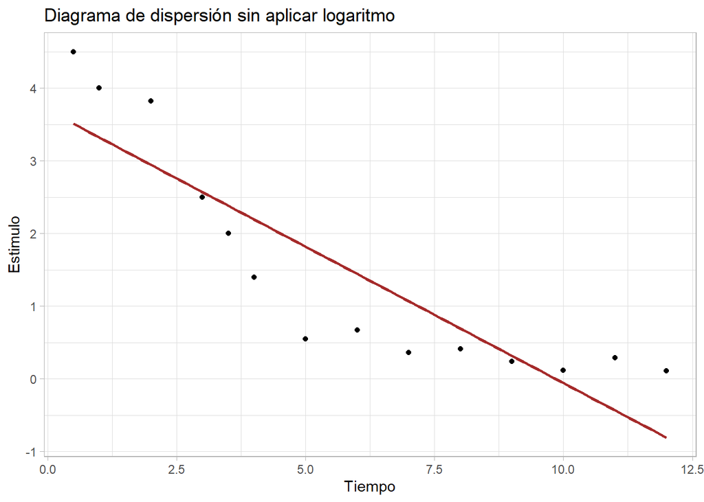

```r
library(ggplot2)
ggplot(estimulo, aes(x=Tiempo, y=Estimulo)) +
  geom_point() +
  geom_smooth(method='lm', formula=y~x, se=FALSE,col='brown') +
  theme_light() +
  ggtitle("Diagrama de dispersión sin aplicar logaritmo")
```

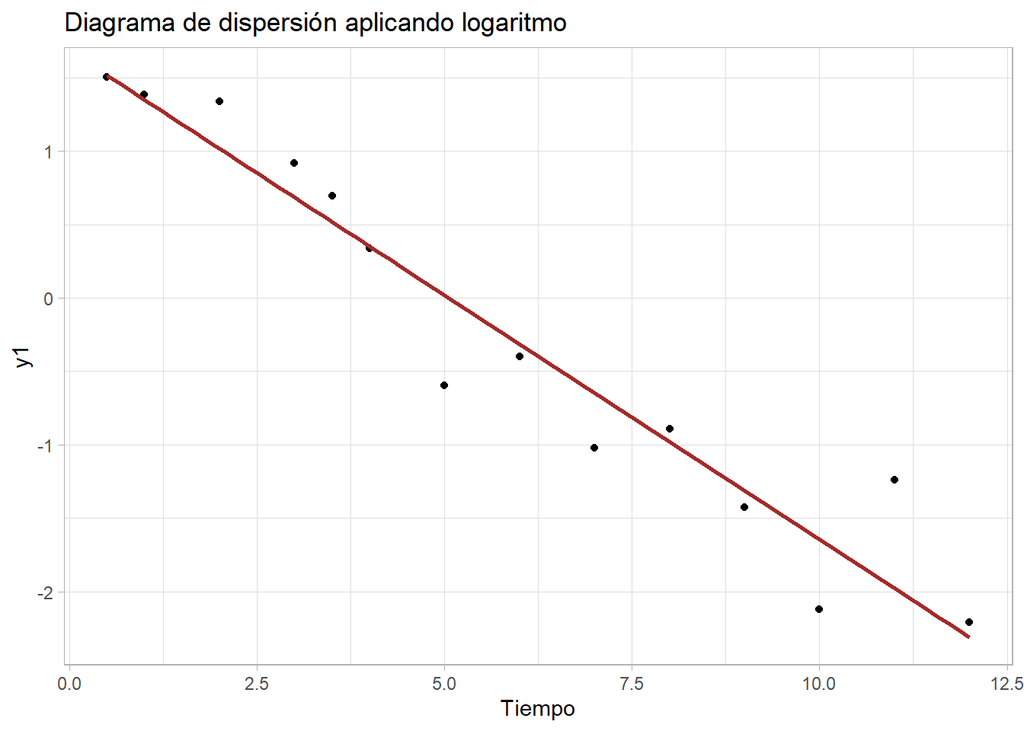

```r
library(ggplot2)
y1 <- log(estimulo$Estimulo)
ggplot(estimulo, aes(x=Tiempo, y=y1)) +
  geom_point() +
  geom_smooth(method='lm', formula=y~x, se=FALSE,col='brown') +
  theme_light() +
  ggtitle("Diagrama de dispersión aplicando logaritmo")
```

Solo como observación, si hicieramos un modelo lineal con las variables originales obtendríamos:

- Que las dos variables son significativas para el modelo pero solo alcanzamos una R-cuadrada ajustada de 76.3%. Y este modelo hace referencia al primer diagrama de dispersión.

```r
mod2 <- lm(Estimulo ~ Tiempo , data = estimulo)
summary(mod2)
```

```
##
## Call:
## lm(formula = Estimulo ~ Tiempo, data = estimulo)
##
## Residuals:
##      Min       1Q   Median       3Q      Max
## -1.26959 -0.62732 -0.07424  0.71164  0.99133
##
## Coefficients:
##             Estimate Std. Error t value Pr(>|t|)
## (Intercept)  3.69634    0.39441   9.372 7.18e-07 ***
## Tiempo      -0.37535    0.05733  -6.547 2.74e-05 ***
## ---
## Signif. codes:  0 '***' 0.001 '**' 0.01 '*' 0.05 '.' 0.1 ' ' 1
##
## Residual standard error: 0.7739 on 12 degrees of freedom
## Multiple R-squared:  0.7813, Adjusted R-squared:  0.763
## F-statistic: 42.86 on 1 and 12 DF,  p-value: 2.743e-05
```

```r
mod3 <- lm(Estimulo ~ exp(Tiempo),data = estimulo)
summary(mod3)
```

```
##
## Call:
## lm(formula = Estimulo ~ exp(Tiempo), data = estimulo)
##
## Residuals:
##     Min      1Q  Median      3Q     Max
## -1.3944 -1.2668 -0.4993  0.7007  2.7581
##
## Coefficients:
##               Estimate Std. Error t value Pr(>|t|)
## (Intercept)  1.742e+00  4.464e-01   3.902   0.0021 **
## exp(Tiempo) -1.327e-05  9.543e-06  -1.391   0.1896
## ---
## Signif. codes:  0 '***' 0.001 '**' 0.01 '*' 0.05 '.' 0.1 ' ' 1
##
## Residual standard error: 1.536 on 12 degrees of freedom
## Multiple R-squared:  0.1388, Adjusted R-squared:  0.067
## F-statistic: 1.933 on 1 and 12 DF,  p-value: 0.1896
```

**Conclusión:** El mejor modelo que podemos tener es el **mod1** y este nos ayudará a realizar predicciones.

### Predicciones

```r
nuevo <- data.frame(Tiempo = 4)
predict(object=mod1, newdata=nuevo, interval="confidence", level=0.95)
```

```
##         fit       lwr       upr
## 1 0.3519415 0.1185537 0.5853294
```

```r
predict(object=mod1, newdata=nuevo, interval="prediction", level=0.95)
```

```
##         fit        lwr      upr
## 1 0.3519415 -0.4587999 1.162683
```

De la tabla original, si el tiempo es 4, el estímulo es 1.4.

En una primer instancia podemos pensar que la predicción es mala, pero recordemos que el modelo es para log(Estimulo), no sobre la variable original.

Por lo que la predicción, en términos de la variable original es:

```r
cat("La predicción del estímulo para Tiempo = 4 es: ", exp(0.3519415))
```

```
## La predicción del estímulo para Tiempo = 4 es:  1.421825
```

### Verificación de supuestos

```
## Non-constant Variance Score Test
## Variance formula: ~ fitted.values
## Chisquare = 2.195525, Df = 1, p = 0.13841
```

De la prueba de homocedasticidad se obtiene un p-value de 0.13841 por lo cual la varianza es constante.

```
##
##  Shapiro-Wilk normality test
##
## data:  residuals(mod1)
## W = 0.96208, p-value = 0.7572
```

Por otro lado, de la prueba de normalidad se obtiene un p-value de 0.7572 por lo que los errores sí están distribuidos de manera normal.

## Caso general

Un caso mas general de la regresión exponencial con una sola variable predictora es:
$$Y = \beta_0 + (\alpha -
\beta_0) e^{\beta_1 (X - \delta)} + \epsilon$$
donde $\alpha$ y $\delta$ son constantes; $\beta_0$ y $\beta_1$ son los coeficientes de regresión.

Ejemplo: Consideremos la base de datos cloro, que contiene la cantidad de cloro (Y) en muestras de un producto en función del numero de semanas (X) desde que se produjo. Se sabe que se puede ajustar el siguiente modelo a los datos:
$$Y = \beta_0 +
(0.49 - \beta_0) e^{-\beta_1 (X - 8)} + \epsilon$$

```r
Cloro <- read.csv("C:/Users/Alumno 25-B/Documents/Osmar/Ejercicios/Analitica/Trabajo 14/cloro.csv")
print(Cloro)
```

```
##    Semanas Cloro
## 1        8  0.49
## 2        8  0.49
## 3       10  0.48
## 4       10  0.47
## 5       10  0.48
## 6       10  0.47
## 7       12  0.46
## 8       12  0.46
## 9       12  0.45
## 10      12  0.43
## 11      14  0.45
## 12      14  0.43
## 13      14  0.43
## 14      16  0.44
```

[output cut: 30 more lines]

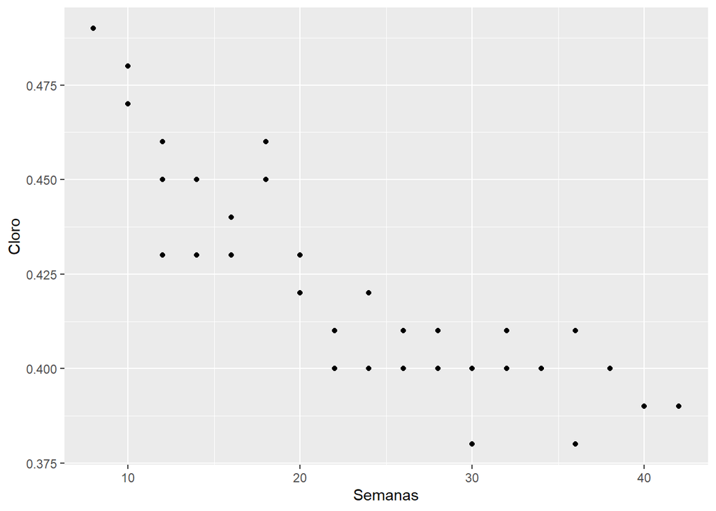

```r
ggplot(Cloro, aes(x=Semanas,y=Cloro))+
  geom_point()
```

Para el modelo necesitamos encontrar los valores de las constantes $\alpha$ y $\delta$, que se obtendrán al analizar la base de datos. En este tipo de regresión, $\delta$ es el valor de inicio para la variable independiente y $\alpha$ es el valor de inicio para la variable dependiente.

En nuestro ejemplo: $\alpha = 0.49$ y $\delta = 8$. Con estos valores podemos ya generar nuestro modelo

```r
#Definir la función
expo<-function(x,b,c){return(b+(0.49-b)*exp(c*(x-8)))} #b y c son los par?metros de la funci?n

#La función "nls" realiza la regresión exponencial
ajuste <- nls(data=Cloro, formula = Cloro~expo(Semanas,b,c),start=list(b=-1,c=-0.1),trace=T)
```

```
## 42.20963    (9.19e+01): par = (-1 -0.1)
## 0.005009005 (3.82e-02): par = (0.3901346 -0.100107)
## 0.005001681 (5.64e-04): par = (0.3901346 -0.1015982)
## 0.005001680 (8.86e-06): par = (0.3901398 -0.1016319)
```

```r
#para b y c se deben dar valores iniciales. Si la el modelo es creciente, se toman positivos y si es decreciente, se toman negativos.
```

El resumen del modelo es:

```r
summary(ajuste)
```

```
##
## Formula: Cloro ~ expo(Semanas, b, c)
##
## Parameters:
##    Estimate Std. Error t value Pr(>|t|)
## b  0.390140   0.005045  77.332  < 2e-16 ***
## c -0.101632   0.013360  -7.607 1.99e-09 ***
## ---
## Signif. codes:  0 '***' 0.001 '**' 0.01 '*' 0.05 '.' 0.1 ' ' 1
##
## Residual standard error: 0.01091 on 42 degrees of freedom
##
## Number of iterations to convergence: 3
## Achieved convergence tolerance: 8.857e-06
```

```r
deviance(ajuste)
```

```
## [1] 0.00500168
```

## Regresión exponencial con más variables

```r
library("rgl")
library("magick")
material <- read.csv("C:/Users/Alumno 25-B/Documents/Osmar/Ejercicios/Analitica/Trabajo 14/material.csv")
```

```r
Tiempo <- material$Tiempo
Temperatura <- material$Temperatura
Material <- material$Material
```

```r
plot3d(Tiempo, Temperatura, Material,
       type = "s", radius = 1.5 )
```

[output not shown]

Veamos ahora cómo realizaremos el análisis.

```r
# b y c son los coeficientes \beta1 y \beta2
# x y y son las variables predictoras: x = x_1 (tiempo) y y = x_2 (temperatura)
expo<-function(x,y,b,c){return(exp(b*x*exp(-c*((1/y)-(1/620)))))}
ajuste <- nls(data=material, formula = Material~expo(Tiempo,Temperatura,b,c),
              start=list(b=0.3,c=0.3),trace=T)
```

```
## 2.440807e+39 (7.62e+04): par = (0.3 0.3)
## 3.303275e+38 (7.27e+04): par = (0.2933333 141.3069)
## 4.470499e+37 (7.09e+04): par = (0.2866667 300.1879)
## 6.050167e+36 (7.14e+04): par = (0.28 480.7046)
## 8.188015e+35 (7.48e+04): par = (0.2733333 686.9147)
## 1.108128e+35 (8.18e+04): par = (0.2666667 922.5561)
## 1.499689e+34 (9.38e+04): par = (0.26 1190.257)
## 2.029610e+33 (1.12e+05): par = (0.2533333 1490.979)
## 2.746780e+32 (1.36e+05): par = (0.2466667 1824.188)
## 3.717364e+31 (1.51e+05): par = (0.24 2188.655)
## 5.030908e+30 (1.14e+05): par = (0.2333334 2582.935)
## 6.808597e+29 (5.86e+04): par = (0.2266667 3003.44)
## 9.214439e+28 (2.87e+04): par = (0.22 3432.302)
## 1.247039e+28 (1.70e+04): par = (0.2133334 3796.396)
## 1.687685e+27 (1.22e+04): par = (0.2066667 3989.532)
## 2.284034e+26 (9.29e+03): par = (0.2 4065.319)
## 3.091106e+25 (7.10e+03): par = (0.1933334 4097.011)
## 4.183359e+24 (5.43e+03): par = (0.1866667 4110.892)
## 5.661564e+23 (4.15e+03): par = (0.18 4116.875)
## 7.662099e+22 (3.18e+03): par = (0.1733334 4119.196)
## 1.036953e+22 (2.43e+03): par = (0.1666667 4119.798)
## 1.403365e+21 (1.86e+03): par = (0.16 4119.617)
## 1.899251e+20 (1.42e+03): par = (0.1533334 4119.124)
## 2.570364e+19 (1.09e+03): par = (0.1466667 4118.576)
## 3.478623e+18 (8.30e+02): par = (0.14 4118.141)
## 4.707836e+17 (6.34e+02): par = (0.1333333 4117.951)
## 6.371435e+16 (4.84e+02): par = (0.1266666 4118.14)
## 8.622964e+15 (3.69e+02): par = (0.1199999 4118.864)
## 1.167029e+15 (2.81e+02): par = (0.1133331 4120.313)
## 1.579491e+14 (2.14e+02): par = (0.1066662 4122.73)
## 2.137815e+13 (1.63e+02): par = (0.09999911 4126.424)
## 2.893699e+12 (1.24e+02): par = (0.09333178 4131.789)
## 3.917326e+11 (9.38e+01): par = (0.08666396 4139.321)
## 5.304187e+10 (7.08e+01): par = (0.07999531 4149.636)
## 7.184748e+09 (5.33e+01): par = (0.07332521 4163.477)
## 9.738566e+08 (3.99e+01): par = (0.06665259 4181.695)
## 1.321604e+08 (2.97e+01): par = (0.05997558 4205.162)
## 1.797469e+07 (2.19e+01): par = (0.05329088 4234.503)
##        2454655. (1.59e+01): par = (0.04659264 4269.408)
## 337786.7    (1.15e+01): par = (0.0398705 4306.838)
## 47150.98    (8.27e+00): par = (0.03310612 4336.292)
## 6747.005    (6.08e+00): par = (0.02626811 4326.512)
## 998.3497    (4.80e+00): par = (0.01930934 4184.306)
## 149.1385    (4.45e+00): par = (0.01219743 3607.152)
## 19.78229    (4.94e+00): par = (0.005118428 1427.72)
## 2.306962    (1.96e+00): par = (-0.0009144108 -9314.84)
## 0.2700653   (5.31e+00): par = (-0.00261027 44367.67)
## 0.007718883 (8.86e-01): par = (-0.003744964 26261.23)
## 0.004293262 (7.73e-04): par = (-0.003758701 27540.57)
## 0.004293259 (4.55e-06): par = (-0.003758807 27539.05)
```

Los valores estimados para los coeficientes son: $\beta_1 = -0.003758807$ y $\beta_2 = 27539.05$. Y con el resumen del modelo podemos observar que los dos son significativos.

```r
summary(ajuste)
```

```
##
## Formula: Material ~ expo(Tiempo, Temperatura, b, c)
##
## Parameters:
##     Estimate Std. Error t value Pr(>|t|)
## b -3.759e-03  4.054e-05  -92.73   <2e-16 ***
## c  2.754e+04  3.308e+02   83.24   <2e-16 ***
## ---
## Signif. codes:  0 '***' 0.001 '**' 0.01 '*' 0.05 '.' 0.1 ' ' 1
##
## Residual standard error: 0.01092 on 36 degrees of freedom
##
## Number of iterations to convergence: 49
## Achieved convergence tolerance: 4.548e-06
```

```r
# Un buen modelo tiene un valor cercano a 0
deviance(ajuste)
```

```
## [1] 0.004293259
```

Al observar esta deviación, podemos decir que el modelo es bueno.

### Predicciones

```r
#Obtenemos los valores obtenidos para b y c
(b_ajustado <- ajuste$m$getPars()["b"])
```

```
##            b
## -0.003758807
```

```r
(c_ajustado <- ajuste$m$getPars()["c"])
```

```
##        c
## 27539.05
```

```r
#predecimos valores para y.
library(tidyverse)
(fitData <- tibble(Tiempo=c(120,125), Temperatura=c(600, 620), fit = expo(Tiempo,Temperatura,b_ajustado,c_ajustado)))
```

```
## # A tibble: 2 × 3
##   Tiempo Temperatura   fit
##    <dbl>       <dbl> <dbl>
## 1    120         600 0.902
## 2    125         620 0.625
```